# Intro Datenanalyse 2

# Die logistische Regression

## Agresti - [**Categorical Data Analysis (2002)**](https://mathdept.iut.ac.ir/sites/mathdept.iut.ac.ir/files/AGRESTI.PDF)

[figure not shown]

- Sehr intuitiv geschriebenes Buch
- Sehr detailliertes Skript von [**Laura A. Thompson**](http://statweb.stanford.edu/~owen/courses/306a/Splusdiscrete2.pdf)
- Das Buch behandelt die kategoriale Datenanalyse ganz grundsätzlich.

## Faraway Bücher zum Thema Regression

[figure not shown]

- Logistische Regression eingängig erklärt
- Beispiel mit R-Code
  - Faraway - [**Extending the linear model with R**](http://www.maths.bath.ac.uk/~jjf23/ELM/scripts2/index.html)
  - Faraway - [**Practical Regression and Anova using R**](https://cran.r-project.org/doc/contrib/Faraway-PRA.pdf)

## Importieren des GESIS Panels Datensatzes

```r
library(readstata13)
path <- "D:/Daten/GitLab/IntroDataAnalysis/data/"
datf <- read.dta13(paste0(path,"ZA5666_v1-0-0_Stata14.dta"),
                  convert.factors = F)
```

Das Argument `convert.factors`:

- `logical`. Wenn TRUE, werden Faktoren aus dem Stata Werte Labeln erzeugt.

## Eine Funktion um fehlende Werte zu rekodieren

```r
code_miss <- function(var){
  misvals <- c(-11,-22,-33,-44,-55,-66,-77,-88,-99,-111)
  var[var %in% misvals] <- NA
  return(var)
}
```

## Variablen für das `glm`

- a11d056z: Altersgruppe

```r
table(datf$a11d056z)
```

```
##
## -99   1   2   3   4   5   6   7   8   9  10  11  12  13
##   5  31  87 101  91  83 100 163 159 133  64  56 105  44
```

```r
age <- code_miss(datf$a11d056z)
```

```r
table(age)
```

```
## age
##   1   2   3   4   5   6   7   8   9  10  11  12  13
##  31  87 101  91  83 100 163 159 133  64  56 105  44
```

## GP Variable a11d094a: Kinder unter 16 Jahre

Leben in Ihrem Haushalt Kinder unter 16 Jahren?

- 1 Ja
- 2 Nein

```r
children <- as.factor(code_miss(datf$a11d094a))
table(children)
```

```
## children
##   1   2
## 325 681
```

## Conditional Density Plot (GESIS Panel)

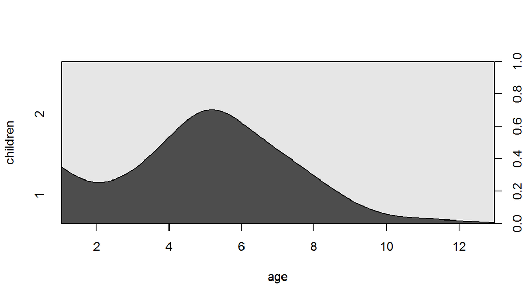

```r
cdplot(children ~ age)
```

## Binäre abhängige Variablen im `glm`

- Die [**logistische Regression**](http://data.princeton.edu/R/glms.html) ghört zur Klasse der generalisierten linearen Modellen (GLM)
- Die Funktion zur Schätzung eines Modells dieser Klasse heißt `glm()`

### Ein `glm` spezifizieren

- Formel-Objekt
- die Klasse (binomial, gaussian, gamma)
- mit einer Link Funktion (logit, probit, cauchit, log, cloglog)

## [Logistische Regression](http://ww2.coastal.edu/kingw/statistics/R-tutorials/logistic.html) mit R

```r
glm_1 <- glm(children ~ age,
                    family = binomial())
```

```r
sum_glm1 <- summary(glm_1)
sum_glm1$coefficients
```

```
##               Estimate Std. Error   z value     Pr(>|z|)
## (Intercept) -0.7194058 0.16384386 -4.390801 1.129338e-05
## age          0.2225862 0.02376266  9.367056 7.458415e-21
```

## [**Die Koeffizienten interpretieren**](https://www.sfu.ca/~jackd/Stat302/Wk12-2_Full.pdf)

Wir betrachten das logistische Modell der Kinder im Haushalt als eine Funktion des Alters.

```r
sum_glm1$coefficients
```

```
##               Estimate Std. Error   z value     Pr(>|z|)
## (Intercept) -0.7194058 0.16384386 -4.390801 1.129338e-05
## age          0.2225862 0.02376266  9.367056 7.458415e-21
```

- Die Schätzungen und Standardfehler werden mit Log Odds angegeben, nicht mit der Wahrscheinlichkeit.
- Die p-Werte bedeuten das Gleiche, wie bei der linearen Regression.

## Der inverse Logit

```r
sum_glm1$coefficients
```

```
##               Estimate Std. Error   z value     Pr(>|z|)
## (Intercept) -0.7194058 0.16384386 -4.390801 1.129338e-05
## age          0.2225862 0.02376266  9.367056 7.458415e-21
```

- Die Koeffizienten können nicht so einfach interpretiert werden
- Wir müssen den inversen Logit verwenden, um etwas auszusagen.

Werte für die Log-odds von 0.2225862 sind das Gleiche, wie die Wahrscheinlichkeit: 0.5554179.

```r
faraway::ilogit(sum_glm1$coefficients[1,1])
```

```
## [1] 0.3275238
```

## Zum Achsenabschnitt in einem logistischen Modell

- Es ist möglich, dass der Schätzwert für den Achsenabschnitt kleiner als null ist.
- Das bedeuted, dass die log-odds negativ sind und NICHT die Wahrscheinlichkeit.
- Ein Log-Odd Wert von 0 bedeuted eine Wahrscheinlichkeit von 0.5.

## Log-odds und die Wahrscheinlichkeit

- Die Log-odds steigen an, wenn die Wahrscheinlichkeit auch ansteigt.

Daraus folgt…

## Das Ergebnis graphisch darstellen

Es resultiert eine Sigmoid-Kurve, anstatt einer Gerade mit konstanter Steigungsrate wie bei der linearen Regression.

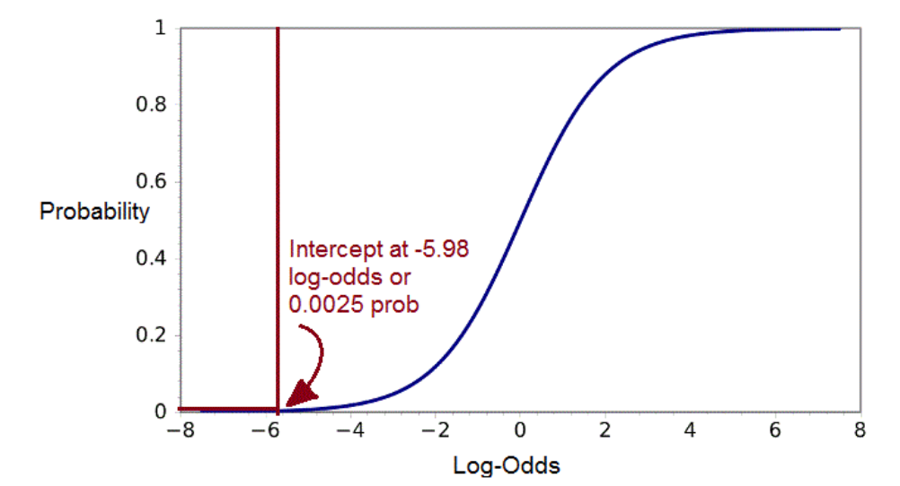

## Logistische Regressionsformel

### Das Modell als Formel:

Log-Odds( Children) = -0.7194058 + 0.2225862(Age) + Fehler

- Wir können Werte in die Formel einsetzen um die vorhergesagten Log-Odds für unterschiedliche Altersklassen zu bekommen.

### Beispiel: Log-Odds für die Altersgruppe 5

-0.7194058 + 0.2225862*(5) = 0.3935251

```r
ilogit(0.3935251)
```

```
## [1] 0.597131
```

## [**Die Ergebnisse interpretieren**](https://www.r-bloggers.com/how-to-perform-a-logistic-regression-in-r/)

```r
anova(glm_1, test="Chisq")
```

[output not shown]

## Die Devianz

### Abweichung vom Idealwert

- Zweimal die Differenz zwischen der maximalen Log-Likelihood $\ell^{(M)}$ und dem Wert für das angepasste Modell
- Je niedriger die Devianz, desto besser.

```r
sum_glm1 <- summary(glm_1)
sum_glm1$deviance
```

```
## [1] 1160.044
```

## [Mc Fadden’s $R^2$](https://www.r-bloggers.com/evaluating-logistic-regression-models/)

```r
library(pscl)
pR2(glm_1)
```

```
##           llh       llhNull            G2      McFadden          r2ML
## -580.02210772 -632.93066002  105.81710461    0.08359297    0.10031573
##          r2CU
##    0.13978426
```

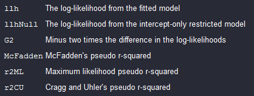

## Großstadtnähe Wohngegend

### Wie weit ist es von Ihrer Wohnung bis ins Zentrum der nächsten Großstadt?

- 1 - Im Großstadtzentrum
- 6 - 60 km und mehr

```r
region <- code_miss(datf$bczd001a)
table(region)
```

```
## region
##   1   2   3   4   5   6
##  87 191 279 157 126 165
```

## Zufriedenheit Leben in Wohnort

### Alles in allem, wie zufrieden sind Sie mit dem Leben in [Wohnort]?

- 1 - Sehr zufrieden
- 5 - Sehr unzufrieden

```r
satisfactionplace <- datf$a11c019a
table(satisfactionplace)
```

```
## satisfactionplace
##   1   2   3   4   5
## 553 534  99  30   6
```

## Ein anderes Modell

```r
glm_2 <- glm(children ~ age + satisfactionplace*region,
                    family = binomial())
```

```r
pseudor2 <- pR2(glm_2)
pseudor2["McFadden"]
```

```
## McFadden
## 0.258121
```

## Eine weitere Variable aus dem GESIS Panel Datensatz

- Anzahl Tattoos:

```r
Tatoos <- code_miss(datf$bdao067a)
Tatoos[Tatoos==97]<-0
```

```r
table(Tatoos)
```

```
## Tatoos
##   0   1   2   3   4   5   6
## 871  56  28  13   7   4   8
```

## Generalisierte Regression mit R - Mehr Funktionen

- Logistisches Modell mit einem Probit Link:

```r
probitmod <- glm(children ~ age,
    family=binomial(link=probit))
```

- Regression mit Zähldaten:

```r
modp <- glm(Tatoos ~ age,family=poisson)
```

- Proportional Odds logistic Regression aus dem Paket `MASS`:

```r
library("MASS")
mod_plr<-polr(a11c020a ~ a11d096b ,data=dat)
```

## Linkliste - logistische Regression

- Einführung in die [**logistische Regression**](http://ww2.coastal.edu/kingw/statistics/R-tutorials/logistic.html)

[figure not shown]

- [**Code zum Buch von Faraway**](http://www.maths.bath.ac.uk/~jjf23/ELM/scripts/binary.R)

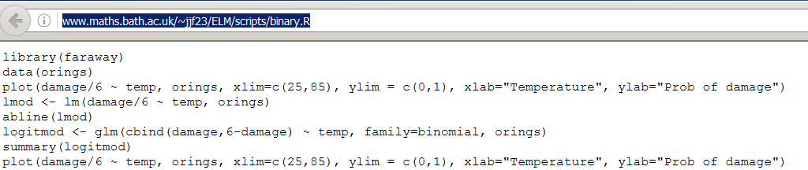

- [**Kategoriale Daten:**](http://homepage.univie.ac.at/herbert.nagel/KategorialeDaten.pdf) - [**Durchführung logistische Regression in R**](https://www.r-bloggers.com/how-to-perform-a-logistic-regression-in-r/)

## Aufgabe - Datenanalyse

- Laden Sie einen Datensatz Ihrer Wahl - entweder einen eigenen oder einen der vorgestellten Datensätze
- Berechnen Sie einfache Statistiken auf den wichtigsten Variablen (Mittelwert, Median, Standardabweichung)
- Erzeugen Sie eine zweidimensionale Häufigkeitstabelle
- Führen Sie eine Regression mit sinnvoll gewählten abhängiger und unabhängiger Variablen auf den Daten durch
- Erzeugen Sie einen Lattice-plot

[Zurück zur Gliederung.](https://github.com/Japhilko/IntroR/blob/master/2017/README.md)

# Faktoren in R

## Was sind Faktoren in R

- Faktoren können eine begrenzte Zahl von Ausprägungen annehmen
- Sie werden oft auch als kategoriale Variablen bezeichnet
- Sie sind vor allem bei der Modellierung wichtig
- Faktoren werden anders behandelt als stetige Variablen
- Wenn man diese Variablen richtig definiert werden sie auch von R richtig behandelt

http://www.stat.berkeley.edu/~s133/factors.html

## Beispiel Definition von Faktoren

```r
data <- c(1,2,2,3,1,2,3,3,1,2,3,3,1)
fdata <- factor(data)
fdata
```

```
##  [1] 1 2 2 3 1 2 3 3 1 2 3 3 1
## Levels: 1 2 3
```

- `labels` direkt definieren

```r
rdata <- factor(data,labels=c("I","II","III"))
rdata
```

```
##  [1] I   II  II  III I   II  III III I   II  III III I
## Levels: I II III
```

## Weitere Möglichkeit der Definition

```r
levels(fdata) <- c('I','II','III')
fdata
```

```
##  [1] I   II  II  III I   II  III III I   II  III III I
## Levels: I II III
```

## Beispiel Monate

```r
mons <- c("March","April","January",
          "November","January","September",
          "October","September","November",
          "August","January","November",
          "November","February","May",
          "August","July","December",
          "August","August","September",
          "November","February","April")
mons <- factor(mons)
table(mons)
```

```
## mons
##     April    August  December  February   January      July     March
##         2         4         1         2         3         1         1
##       May  November   October September
##         1         5         1         3
```

## Beispiel: ordered factor

```r
mons <- factor(mons,levels=c("January","February",
                             "March","April","May","June",
                             "July","August","September",
                             "October","November",
                             "December"),
               ordered=TRUE)

mons[1] < mons[2]
```

```
## [1] TRUE
```

## Rücktransformation

```r
fert <- c(10,20,20,50,10,20,10,50,20)
fert <- factor(fert,levels=c(10,20,50),ordered=TRUE)
fert
```

```
## [1] 10 20 20 50 10 20 10 50 20
## Levels: 10 < 20 < 50
```

```r
mean(fert)
```

```
## [1] NA
```

```r
mean(as.numeric(levels(fert)[fert]))
```

```
## [1] 23.33333
```

## Tabellen mit Faktoren

```r
lets <- sample(letters,size=100,replace=TRUE)
lets <- factor(lets)
table(lets[1:5])
```

```
##
## a b c d e f g h j k l m n o p q r s t u v x y z
## 0 0 1 0 1 0 1 0 0 0 0 1 0 0 0 0 0 0 0 1 0 0 0 0
```

# Grafiken mit ggplot

## Das Paket `ggplot2`

- Entwickelt von Hadley Wickham
- Viele Informationen unter:
- http://ggplot2.org/
- Den Graphiken liegt eine eigene Grammitik zu Grunde

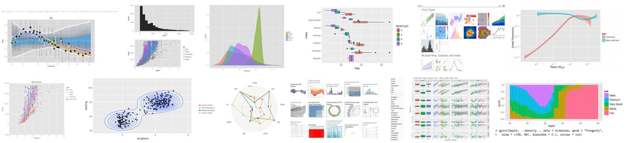

## Einführung in `ggplot2`

http://www.r-bloggers.com/basic-introduction-to-ggplot2/

```r
install.packages("ggplot2")
```

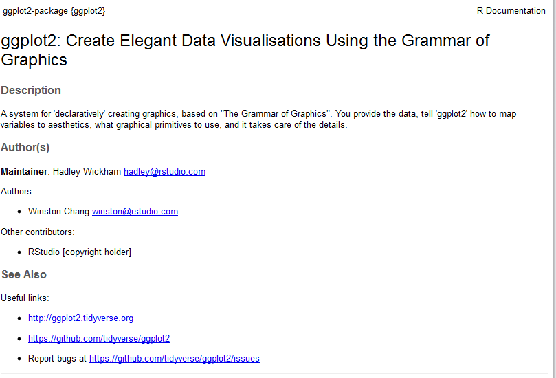

```r
library(ggplot2)
?ggplot2
```

## Der `diamonds` Datensatz

```r
head(diamonds)
```

| carat | cut | color | clarity | depth | table | price | x | y | z |
| --- | --- | --- | --- | --- | --- | --- | --- | --- | --- |
| 0.23 | Ideal | E | SI2 | 61.5 | 55 | 326 | 3.95 | 3.98 | 2.43 |
| 0.21 | Premium | E | SI1 | 59.8 | 61 | 326 | 3.89 | 3.84 | 2.31 |
| 0.23 | Good | E | VS1 | 56.9 | 65 | 327 | 4.05 | 4.07 | 2.31 |
| 0.29 | Premium | I | VS2 | 62.4 | 58 | 334 | 4.20 | 4.23 | 2.63 |
| 0.31 | Good | J | SI2 | 63.3 | 58 | 335 | 4.34 | 4.35 | 2.75 |
| 0.24 | Very Good | J | VVS2 | 62.8 | 57 | 336 | 3.94 | 3.96 | 2.48 |

## Wie nutzt man `qplot`

- Die Funktion `qplot` wird für schnelle Graphiken verwendet (quick plots)
- bei der Funktion `ggplot` kann man alles bis ins Detail kontrollieren

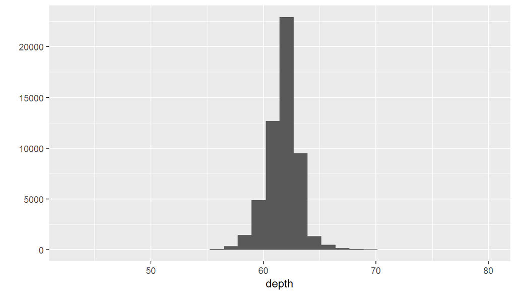

```r
# histogram
qplot(depth, data=diamonds)
```

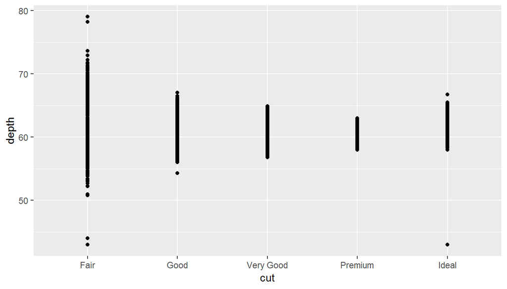

```r
qplot(cut, depth, data=diamonds)
```

## Ein weiteres Balkendiagramm

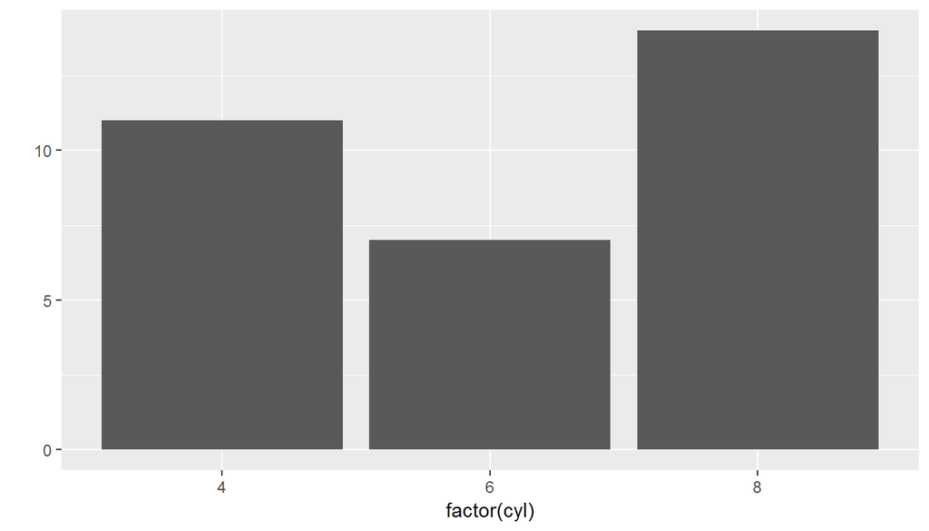

```r
qplot(factor(cyl), data=mtcars,geom="bar")
```

## Boxplot

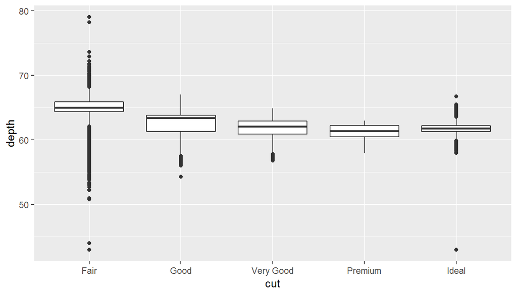

```r
qplot(data=diamonds,x=cut,y=depth,geom="boxplot")
```

## Scatterplot

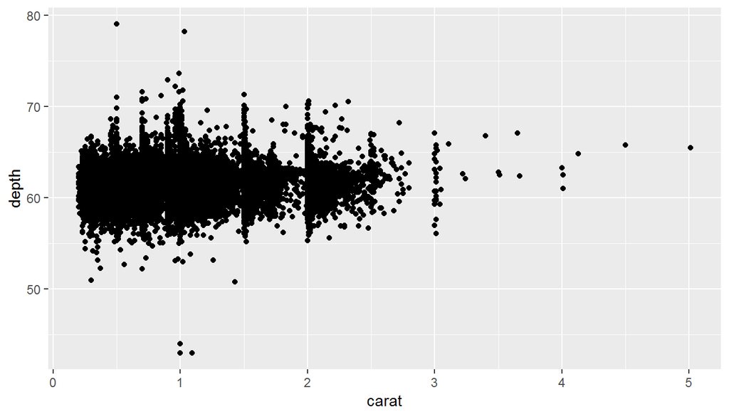

```r
# scatterplot
qplot(carat, depth, data=diamonds)
```

## Farbe hinzu:

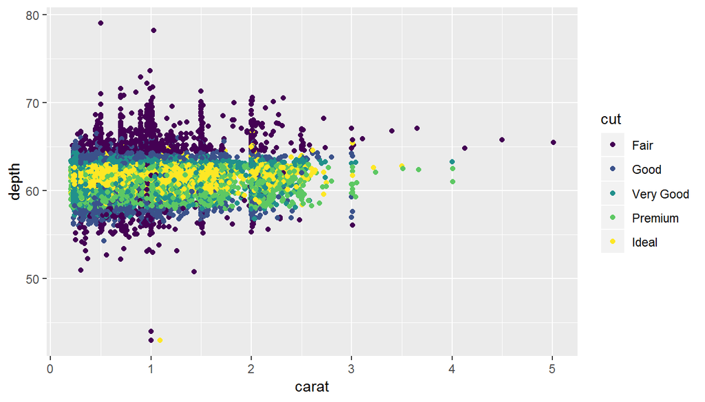

```r
qplot(carat, depth, data=diamonds,color=cut)
```

## Trendlinie hinzufügen

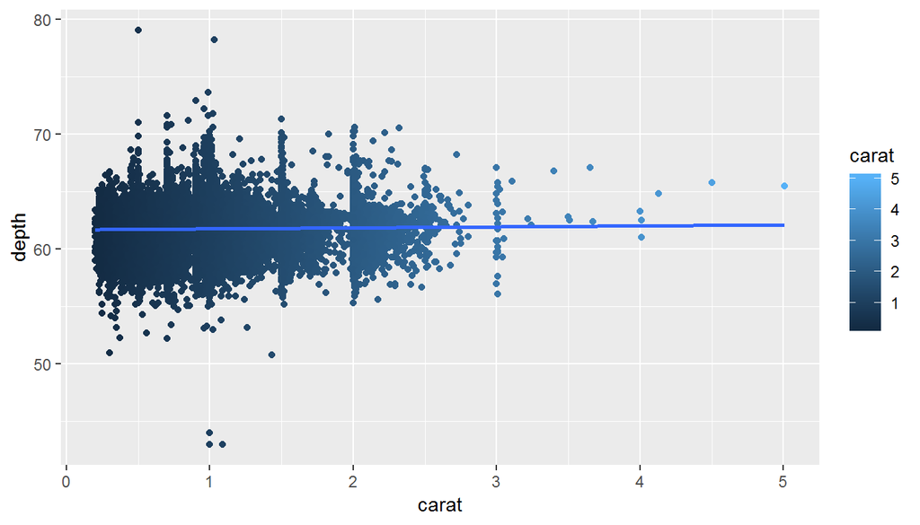

```r
myGG<-qplot(data=diamonds,x=carat,y=depth,color=carat)
myGG + stat_smooth(method="lm")
```

## Graphik drehen

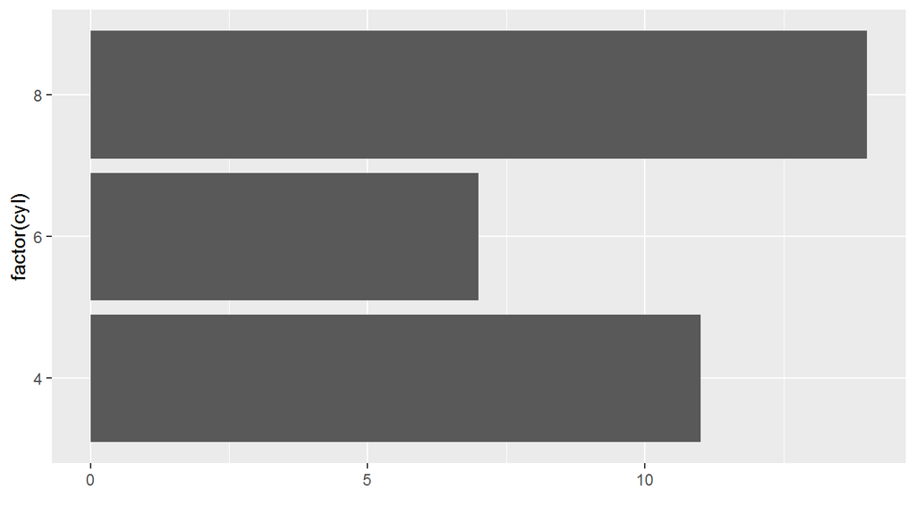

```r
qplot(factor(cyl), data=mtcars, geom="bar") +
coord_flip()
```

## Wie nutzt man ggplot

- die aestetics:

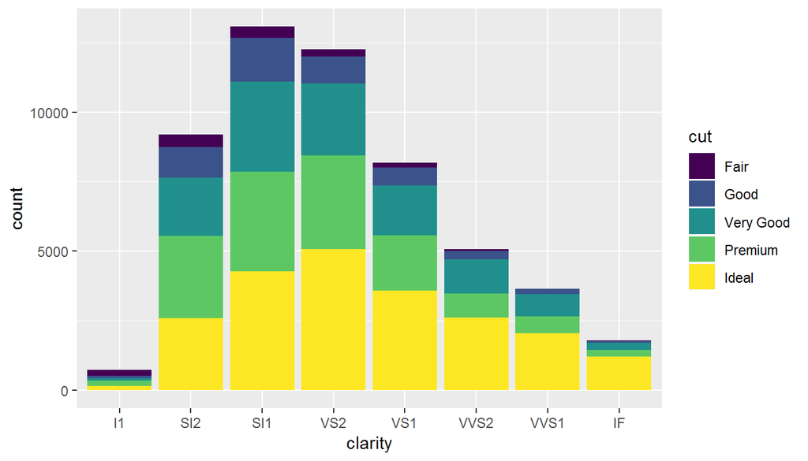

```r
ggplot(diamonds, aes(clarity, fill=cut)) + geom_bar()
```

## Farben selber wählen

Es wird das Paket `RColorBrewer` verwendet um die Farbpalette zu ändern

```r
install.packages("RColorBrewer")
```

```r
library(RColorBrewer)
myColors <- brewer.pal(5,"Accent")
names(myColors) <- levels(diamonds$cut)
colScale <- scale_colour_manual(name = "cut",
                                values = myColors)
```

http://stackoverflow.com/questions/6919025/

## Eine Graphik mit den gewählten Farben

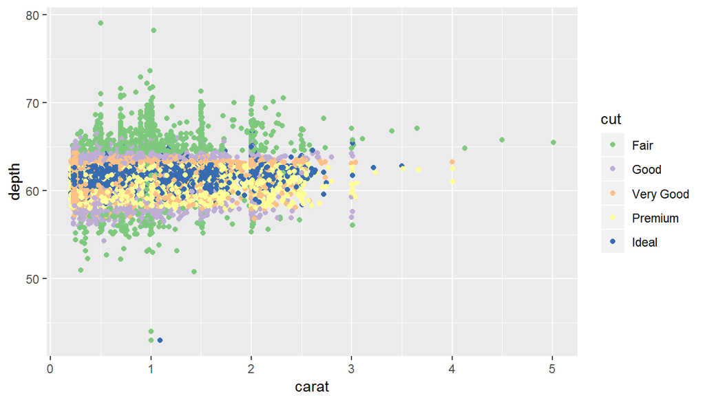

```r
p <- ggplot(diamonds,aes(carat, depth,colour = cut)) +
  geom_point()
p + colScale
```

## Speichern mit ggsave

```r
ggsave("Graphik.jpg")
```

## Links

- [Warum man ggplot2 für einfache Grafiken nutzen sollte](http://www.r-bloggers.com/why-i-use-ggplot2/)

[figure not shown]

- [Einführung in ggplot2](https://opr.princeton.edu/workshops/Downloads/2015Jan_ggplot2Koffman.pdf)

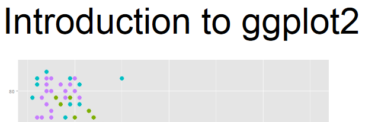

- [ggplot2 Basics](http://tutorials.iq.harvard.edu/R/Rgraphics/Rgraphics.html)

- Noam Ross - [Quick Introduction to ggplot2](http://www.noamross.net/blog/2012/10/5/ggplot-introduction.html)
- [Plugin ggplot2](https://www.r-bloggers.com/rcmdrplugin-kmggplot2_0-2-4-is-on-cran/)

## Beispiel einer [interaktiven Karte](http://rpubs.com/Japhilko82/Campsites)

[interaktiven Karte](http://rpubs.com/Japhilko82/Campsites) und [Rcode](https://raw.githubusercontent.com/Japhilko/GeoData/master/2015/rcode/SpatMA_Interactive%20maps.R) um eine interaktive Karte mit leaflet zu erzeugen.